# Cerag Oguztuzun: Lab 03 for 431

Cerag Oguztuzun

2021-09-27

## Setup

```r
library(palmerpenguins)
library(janitor)
library(broom)
library(tidyverse)

#cleaning penguin data
penguins <- penguins %>%
    filter(complete.cases(body_mass_g, species))
```

## Read in `lab03_counties.csv` for Questions 6-10

```r
lab03_chr <- read_csv("https://raw.githubusercontent.com/THOMASELOVE/431-data/main/lab03_counties.csv", show_col_types = FALSE)
```

# Question 1

I generated a histogram using ggplot, which shows the body masses of penguins in the dataset. This histogram can give us insight about the distribution of percentage of body masses of penguins. The spead is not very skewed but there is varince among the data. I provided the labels, used 10 as a bin number and changed fill color to provide better visualization.

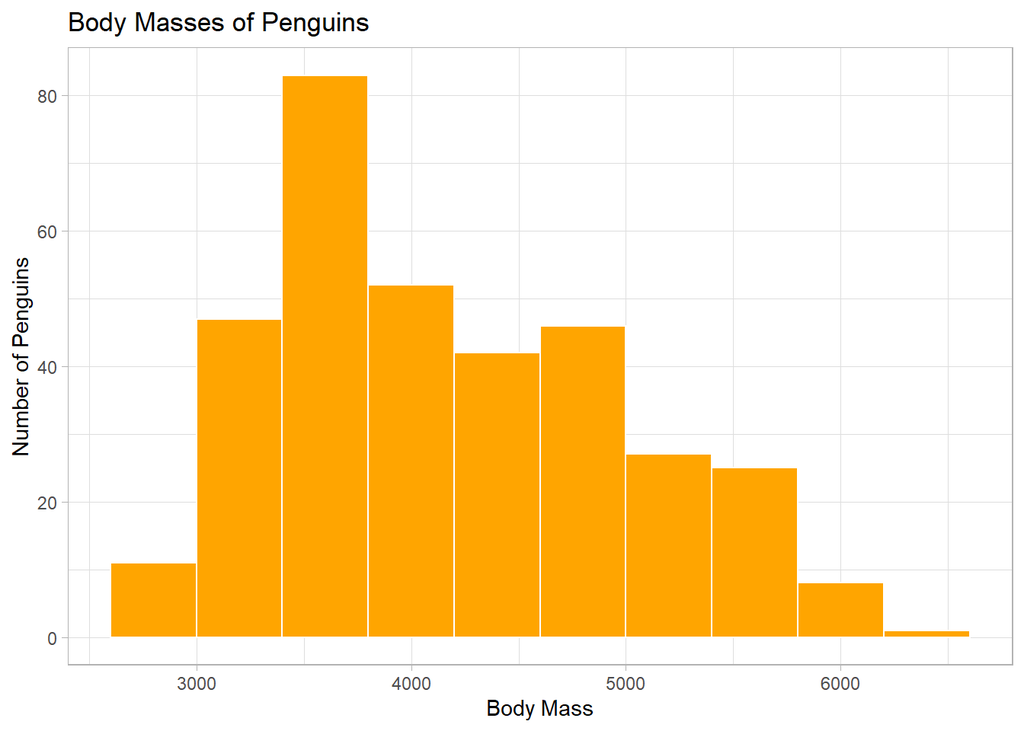

```r
ggplot(penguins, aes(x = body_mass_g)) +
    geom_histogram(bins = 10, col = 'white', fill = "orange") +
    theme_light() +
    labs(title = "Body Masses of Penguins", x = "Body Mass", y = "Number of Penguins")
```

# Question 2

```r
mean_bm <- mean(penguins$body_mass_g, trim = 0)
median_bm <- median(penguins$body_mass_g)
sd_bm <- sd(penguins$body_mass_g)
iqr_bm <- IQR(penguins$body_mass_g)

cat("Mean of Body Mass of Penguins (g): ", mean_bm,"\n")
```

```
Mean of Body Mass of Penguins (g):  4201.754
```

```r
cat("Median of Body Mass of Penguins (g): ", median_bm,"\n")
```

```
Median of Body Mass of Penguins (g):  4050
```

```r
cat("Standard Deviation of Body Mass of Penguins (g): ", sd_bm,"\n")
```

```
Standard Deviation of Body Mass of Penguins (g):  801.9545
```

```r
cat("Interquartile Range of Body Mass of Penguins (g): ", iqr_bm,"\n")
```

```
Interquartile Range of Body Mass of Penguins (g):  1200
```

# Question 3

# Question 4

Body Mass Across Penguin Species histogram is faceted regarding the penguin species. Mean, median, standard deviation and interquartile range of each species are printed as output.

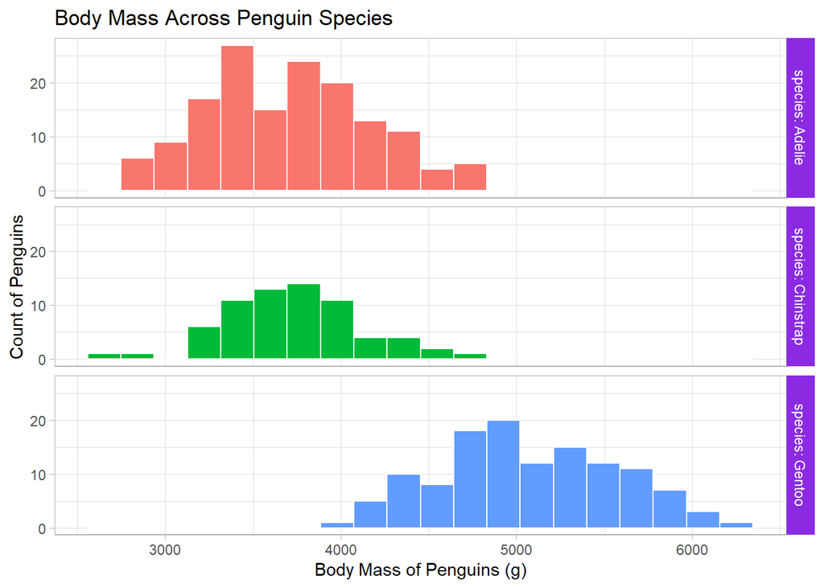

```r
ggplot(penguins, aes( x = body_mass_g, fill = species)) +
    geom_histogram( bins = 20, colour = "white")+
    facet_grid( species ~ ., labeller = "label_both")+
    guides( fill = "none") +
    theme_light() +
    theme( strip.background = element_rect( fill = "blueviolet"))+
    labs( title = "Body Mass Across Penguin Species", x="Body Mass of Penguins (g)", y="Count of Penguins")
```

# Numerical Summary for Adelie Penguins

```r
penguins_adelie <- penguins %>%
    filter(species == "Adelie")

mean_bm <- mean(penguins_adelie$body_mass_g, trim = 0)
median_bm <- median(penguins_adelie$body_mass_g)
sd_bm <- sd(penguins_adelie$body_mass_g)
iqr_bm <- IQR(penguins_adelie$body_mass_g)

cat("Mean of Body Mass of Adelie Penguins: ", mean_bm,"\n")
```

```
Mean of Body Mass of Adelie Penguins:  3700.662
```

```r
cat("Median of Body Mass of Adelie Penguins: ", median_bm,"\n")
```

```
Median of Body Mass of Adelie Penguins:  3700
```

```r
cat("Standard Deviation of Body Mass of Adelie Penguins: ", sd_bm,"\n")
```

```
Standard Deviation of Body Mass of Adelie Penguins:  458.5661
```

```r
cat("Interquartile Range of Body Mass of Adelie Penguins: ", iqr_bm,"\n")
```

```
Interquartile Range of Body Mass of Adelie Penguins:  650
```

# Numerical Summary for Chinstrap Penguins

```r
penguins_chinstrap <- penguins %>%
    filter(species == "Chinstrap")

mean_bm <- mean(penguins_chinstrap$body_mass_g, trim = 0)
median_bm <- median(penguins_chinstrap$body_mass_g)
sd_bm <- sd(penguins_chinstrap$body_mass_g)
iqr_bm <- IQR(penguins_chinstrap$body_mass_g)

cat("Mean of Body Mass of Chinstrap Penguins: ", mean_bm,"\n")
```

```
Mean of Body Mass of Chinstrap Penguins:  3733.088
```

```r
cat("Median of Body Mass of Chinstrap Penguins: ", median_bm,"\n")
```

```
Median of Body Mass of Chinstrap Penguins:  3700
```

```r
cat("Standard Deviation of Body Mass of Chinstrap Penguins: ", sd_bm,"\n")
```

```
Standard Deviation of Body Mass of Chinstrap Penguins:  384.3351
```

```r
cat("Interquartile Range of Body Mass of Chinstrap Penguins: ", iqr_bm,"\n")
```

```
Interquartile Range of Body Mass of Chinstrap Penguins:  462.5
```

# Numerical Summary for Gentoo Penguins

```r
penguins_gentoo <- penguins %>%
    filter(species == "Gentoo")

mean_bm <- mean(penguins_gentoo$body_mass_g, trim = 0)
median_bm <- median(penguins_gentoo$body_mass_g)
sd_bm <- sd(penguins_gentoo$body_mass_g)
iqr_bm <- IQR(penguins_gentoo$body_mass_g)

cat("Mean of Body Mass of Gentoo Penguins: ", mean_bm,"\n")
```

```
Mean of Body Mass of Gentoo Penguins:  5076.016
```

```r
cat("Median of Body Mass of Gentoo Penguins: ", median_bm,"\n")
```

```
Median of Body Mass of Gentoo Penguins:  5000
```

```r
cat("Standard Deviation of Body Mass of Gentoo Penguins: ", sd_bm,"\n")
```

```
Standard Deviation of Body Mass of Gentoo Penguins:  504.1162
```

```r
cat("Interquartile Range of Body Mass of Gentoo Penguins: ", iqr_bm,"\n")
```

```
Interquartile Range of Body Mass of Gentoo Penguins:  800
```

# Question 5

We can observe a Normal distribution for every species’ data. Gento species have the highest body mass among other two species, as It’s mean value is the highest. We cannot easily compare the Chinstrap and Adelie penguins, we can see a similar range of body masses for penguins of that species. However, the number of penguins in Chinstrap is very less than Adelie, maybe addition to body mass data of Chinstrap penguins could enable us to derive a better conclusion. Also, the standard deviation of Gento species is the highest which suggests the spread is the highest among other species. Additionally, histogram of every species’ penguins are symmetric.

# Question 6

```r
set.seed(20212022)

chr_sample <- slice_sample(lab03_chr, n = 750)
chr_sample <- chr_sample %>%
    filter(complete.cases(state, county_name, adult_obesity, food_insecurity))
vars_to_keep <- c("state", "county_name", "adult_obesity", "food_insecurity")
chr_sample <- chr_sample[vars_to_keep]
chr_sample
```

```
# A tibble: 750 x 4
   state county_name         adult_obesity food_insecurity
   <chr> <chr>                       <dbl>           <dbl>
 1 VA    New Kent County             0.341           0.059
 2 OH    Holmes County               0.268           0.102
 3 FL    Holmes County               0.358           0.186
 4 MT    Powder River County         0.232           0.096
 5 MO    Webster County              0.334           0.134
 6 GA    Glascock County             0.306           0.133
 7 SD    Minnehaha County            0.311           0.095
 8 MO    Callaway County             0.363           0.117
 9 MO    Dent County                 0.25            0.167
10 IA    Shelby County               0.337           0.082
# ... with 740 more rows
```

Cuyahoga County in Ohio is among the data.

```r
chr_sample_cc <- chr_sample %>%
    filter(county_name == "Cuyahoga County")

chr_sample_cc
```

```
# A tibble: 1 x 4
  state county_name     adult_obesity food_insecurity
  <chr> <chr>                   <dbl>           <dbl>
1 OH    Cuyahoga County         0.318           0.159
```

The mean of adult_obesity is 0.3345.

```r
mean_ob <- mean(chr_sample$adult_obesity, trim = 0)
cat("Mean of Adult Obesity:", mean_ob,"\n")
```

```
Mean of Adult Obesity: 0.3345027
```

# Question 7

A Normal model for distribution seems to fit this data, we can observe a peak value around 0.35 for Adult Obesity, which is close to the mean that is 0.33. We can say that the mean and median are close, the data is symmetric and not skewed. As the mean and median are close to each other, there are not many outliers in the data as well.

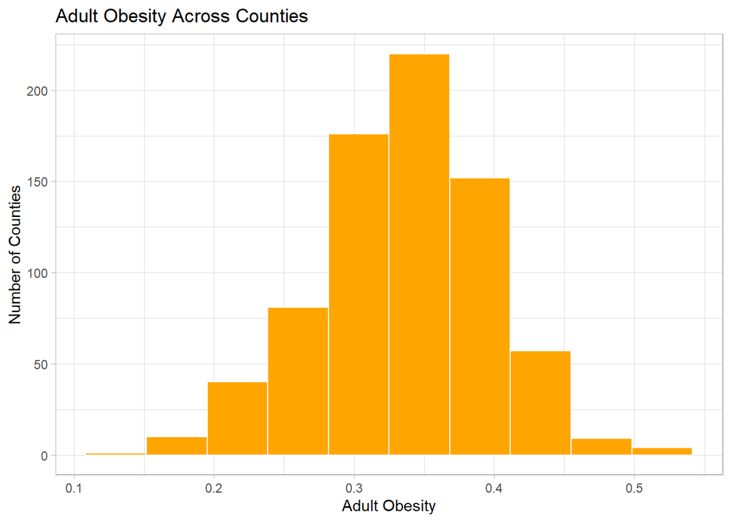

```r
ggplot(chr_sample, aes(x = adult_obesity)) +
    geom_histogram(bins = 10, col = 'white', fill = "orange") +
    theme_light() +
    labs(title = "Adult Obesity Across Counties", x = "Adult Obesity", y = "Number of Counties")
```

# Question 8

From the plot, It can be seen that food insecurity and adult obesity are positively correlated, which implies that when food insecurity increases adult obesity also increases and vica versa. From the smooth line, we can state that a liner model seems appropriate to describe this relationship between food insecurity and adult obesity. However, the slope of the line is not very steep, which suggests a p value near zero. But the slope is also not zero, which would mean poor correlation and poor fit to linear model. Hence, we can conclude that food insecurity and adult obesity are correlated between a weak and a strong point.

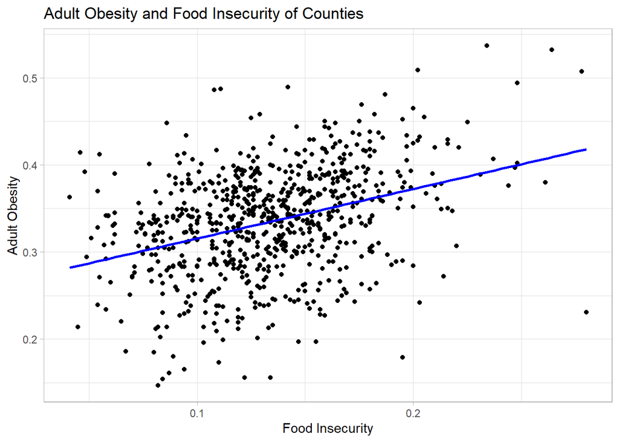

```r
ggplot(chr_sample, aes(x = food_insecurity, y = adult_obesity)) +
    geom_point() +
    theme_light() +
    geom_smooth(method = "lm", formula = y ~ x,
                col = "blue", se = FALSE)+
    labs(title = "Adult Obesity and Food Insecurity of Counties", x = "Food Insecurity", y = "Adult Obesity")
```

# Question 9

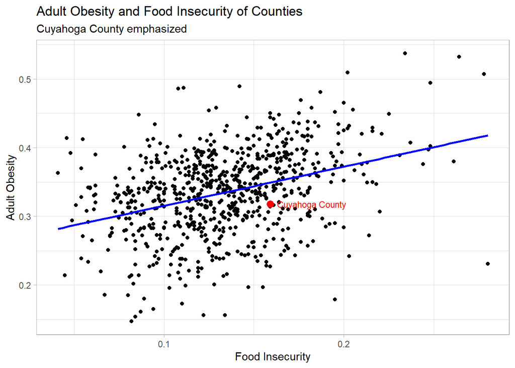

```r
ggplot(chr_sample, aes(x = food_insecurity, y = adult_obesity)) +
    geom_point() +
    geom_point(data=chr_sample %>% filter(county_name == "Cuyahoga County"),
               color='red',
               size=3) +
    geom_text(data=chr_sample %>% filter(county_name == "Cuyahoga County"),
              aes(label="Cuyahoga County", hjust = -0.1),
               color='red',
               size=3) +
    theme_light() +
    geom_smooth(method = "lm", formula = y ~ x,
                col = "blue", se = FALSE)+
    labs(title = "Adult Obesity and Food Insecurity of Counties", x = "Food Insecurity", y = "Adult Obesity", subtitle="Cuyahoga County emphasized")
```

# Question 10

Reflecting on Spiegelhalter, in order to state a causality, we have to establish a number of factors in our data. We should have control groups where other variables are held constant such that we can observe the relationship between food insecurity and adult obesity better. We should have an allocation of treatment, which means the comparisons groups in the data should be as similar as possible. If we narrow our analysis regarding these, the causality between adult obesity and food insecurity can be better analyzed.